# Data Visualization Project 2 Tableau Story

TB Burden by Country:Tuberculosis (TB) trends worldwide

SAMUEL NUKPORFE Northeastern University INSH 5302: Information Design and Visual Analytics

March 18, 2025

> How does the burden of tuberculosis vary across different WHO regions over time, and what are the relationships between key TB indicators such as prevalence, incidence among HIV-positive individuals, and case detection rates?.

In this analysis, I explored the “TB Burden by Country” dataset to understand global tuberculosis trends. I began by cleaning the data, selecting key variables such as TB prevalence, TB incidence among HIV-positive individuals, and case detection rates, and then removed any null values to ensure robust analysis. Using this refined dataset, I generated summary statistics for each variable, providing insight into the distribution and variability of the key public health indicators. I also created several visualizations—including line charts, scatter plots, and bar charts—to compare trends over time and across WHO regions. These visualizations help reveal regional differences and correlations between various TB metrics, making the data more accessible and actionable.

The visualizations were developed using the ggplot2 package, while features and the kableExtra package was used for presenting summary statistics in a clear, formatted table. This combination of tools allowed for both detailed numerical analysis and engaging graphical representations. The analysis offers a comprehensive look at the TB burden across different countries and regions, highlighting the importance of effective case detection and public health monitoring. Overall, this project not only demonstrates various data manipulation and visualization techniques in R but also provides valuable insights into global health trend

## Data

### Load Libraries and Packages

```r
library(readr)
library(dplyr)
library(tidyr)
library(ggplot2)
library(knitr)
library(rmarkdown)
library(mosaic)
library(kableExtra)
```

### Description of data

I chose the “TB Burden by Country” dataset, a public data resource available through Tableau’s sample data repository, which provides detailed information on tuberculosis metrics across various countries. This dataset includes key variables such as TB prevalence per 100,000 population, incidence of TB cases among HIV-positive individuals, and case detection rates, along with demographic data like population estimates and country classifications by WHO region. While the data isn’t housed within a specific R package, it’s accessible as a CSV file and is perfect for demonstrating data manipulation and visualization techniques in R.

I selected this dataset because it offers a rich opportunity to explore public health trends through a global lens. The availability of multiple key metrics and time series information enables comprehensive analysis, from calculating summary statistics using the mosaic package to creating insightful visualizations with ggplot2 and kableExtra. This blend of quantitative and categorical data makes it an ideal choice for illustrating data cleaning, transformation, and visualization processes in an R Markdown project, providing both depth and practical relevance in the field of public health.

> Topic: Health

> Data set: TB Burden by Country

### Load and Clean Data

```r
url <- "https://public.tableau.com/app/sample-data/TB_Burden_Country.csv"
tb_data <- read_csv(url)

tb_clean <- tb_data %>%
  select(`Country or territory name`, Region, Year,
         `Estimated total population number`,
         `Estimated prevalence of TB (all forms) per 100 000 population`,
         `Estimated incidence of TB cases who are HIV-positive per 100 000 population`,
         `Case detection rate (all forms), percent`) %>%
  drop_na()
```

### Preview Data

```r
head(tb_clean, 10)
```

| Country or territory name | Region | Year | Estimated total population number | Estimated prevalence of TB (all forms) per 100 000 population | Estimated incidence of TB cases who are HIV-positive per 100 000 population | Case detection rate (all forms), percent |
| --- | --- | --- | --- | --- | --- | --- |
| Afghanistan | EMR | 1990 | 11731193 | 306 | 0.11 | 20.0 |
| Afghanistan | EMR | 1991 | 12612043 | 343 | 0.13 | 96.0 |
| Afghanistan | EMR | 1997 | 19021226 | 448 | 0.28 | 3.6 |
| Afghanistan | EMR | 1998 | 19496836 | 454 | 0.30 | 8.3 |
| Afghanistan | EMR | 1999 | 19987071 | 446 | 0.32 | 8.7 |
| Afghanistan | EMR | 2000 | 20595360 | 430 | 0.34 | 18.0 |
| Afghanistan | EMR | 2001 | 21347782 | 414 | 0.36 | 25.0 |
| Afghanistan | EMR | 2002 | 22202806 | 397 | 0.38 | 33.0 |
| Afghanistan | EMR | 2003 | 23116142 | 377 | 0.40 | 32.0 |
| Afghanistan | EMR | 2004 | 24018682 | 361 | 0.42 | 41.0 |

### Variables

```r
names(tb_clean)
```

```
## [1] "Country or territory name"
## [2] "Region"
## [3] "Year"
## [4] "Estimated total population number"
## [5] "Estimated prevalence of TB (all forms) per 100 000 population"
## [6] "Estimated incidence of TB cases who are HIV-positive per 100 000 population"
## [7] "Case detection rate (all forms), percent"
```

The variables featured in this data visualization project are:

1.Country or territory name:This is a categorical variable that represents the name of the country or territory where the TB data was recorded

2.Region:This categorical variable indicates the geographic region (such as EMR, AFR, etc.) that the country belongs to, helping to group and compare data across broader areas

3.Year: his is an interval variable representing the specific year in which the data was collected. It is crucial for time-based analyses and trend visualizations.

4.Estimated total population number: This quantitative variable shows the estimated population of the country for a given year. It provides context for the TB metrics and allows normalization if necessary

5.Estimated prevalence of TB (all forms) per 100,000 population: This quantitative variable measures the number of existing TB cases (across all forms) per 100,000 people, indicating the overall burden of TB in the population

6.Estimated incidence of TB cases who are HIV-positive per 100,000 population:This quantitative variable quantifies the number of new TB cases among HIV-positive individuals per 100,000 population, highlighting the intersection of TB and HIV

7.Case detection rate (all forms), percent:This quantitative variable, expressed as a percentage, indicates the proportion of TB cases that are detected relative to the estimated total number of cases. It reflects the effectiveness of TB surveillance and diagnostic systems * * *

# Data Analysis

## Required Analysis

### Chart/Graph

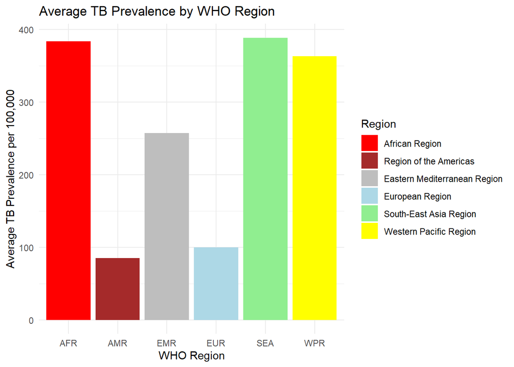

```r
tb_by_region <- tb_clean %>%
  group_by(Region) %>%
  summarise(
    avg_prevalence = mean(`Estimated prevalence of TB (all forms) per 100 000 population`, na.rm = TRUE)
  )

# Create a bar chart with a custom legend showing full region names
p_region <- ggplot(tb_by_region, aes(x = Region, y = avg_prevalence, fill = Region)) +
  geom_bar(stat = "identity") +
  scale_fill_manual(
    values = c("AFR" = "red",
               "AMR" = "brown",
               "EMR" = "gray",
               "EUR" = "lightblue",
               "SEA" = "lightgreen",
               "WPR" = "yellow"),
    labels = c("AFR" = "African Region",
               "AMR" = "Region of the Americas",
               "EMR" = "Eastern Mediterranean Region",
               "EUR" = "European Region",
               "SEA" = "South-East Asia Region",
               "WPR" = "Western Pacific Region")
  ) +
  labs(
    title = "Average TB Prevalence by WHO Region",
    x = "WHO Region",
    y = "Average TB Prevalence per 100,000",
    fill = "Region"
  ) +
  theme_minimal()

# Print the plot
p_region
```

### Summary Statistics

```r
prev_stats <- favstats(tb_clean$`Estimated prevalence of TB (all forms) per 100 000 population`) %>%
  select(min, Q1, median, mean, Q3, max, sd) %>%
  mutate(Variable = "TB Prevalence per 100k") %>%
  relocate(Variable)

inc_stats <- favstats(tb_clean$`Estimated incidence of TB cases who are HIV-positive per 100 000 population`) %>%
  select(min, Q1, median, mean, Q3, max, sd) %>%
  mutate(Variable = "TB Incidence (HIV+) per 100k") %>%
  relocate(Variable)

detect_stats <- favstats(tb_clean$`Case detection rate (all forms), percent`) %>%
  select(min, Q1, median, mean, Q3, max, sd) %>%
  mutate(Variable = "Case Detection Rate (%)") %>%
  relocate(Variable)

stats_df <- bind_rows(prev_stats, inc_stats, detect_stats)

stats_df %>%
  kable("html", caption = "Summary Statistics for TB Variables", digits = 2) %>%
  kable_styling(full_width = FALSE, bootstrap_options = c("striped", "hover", "condensed"))
```

Summary Statistics for TB Variables

|  | Variable | min | Q1 | median | mean | Q3 | max | sd |
| --- | --- | --- | --- | --- | --- | --- | --- | --- |
| …1 | TB Prevalence per 100k | 1.2 | 32.00 | 126 | 231.80 | 340 | 1762 | 278.53 |
| …2 | TB Incidence (HIV+) per 100k | 0.0 | 0.19 | 2 | 40.11 | 14 | 1063 | 125.66 |
| …3 | Case Detection Rate (%) | 0.0 | 48.00 | 69 | 65.06 | 84 | 320 | 24.80 |

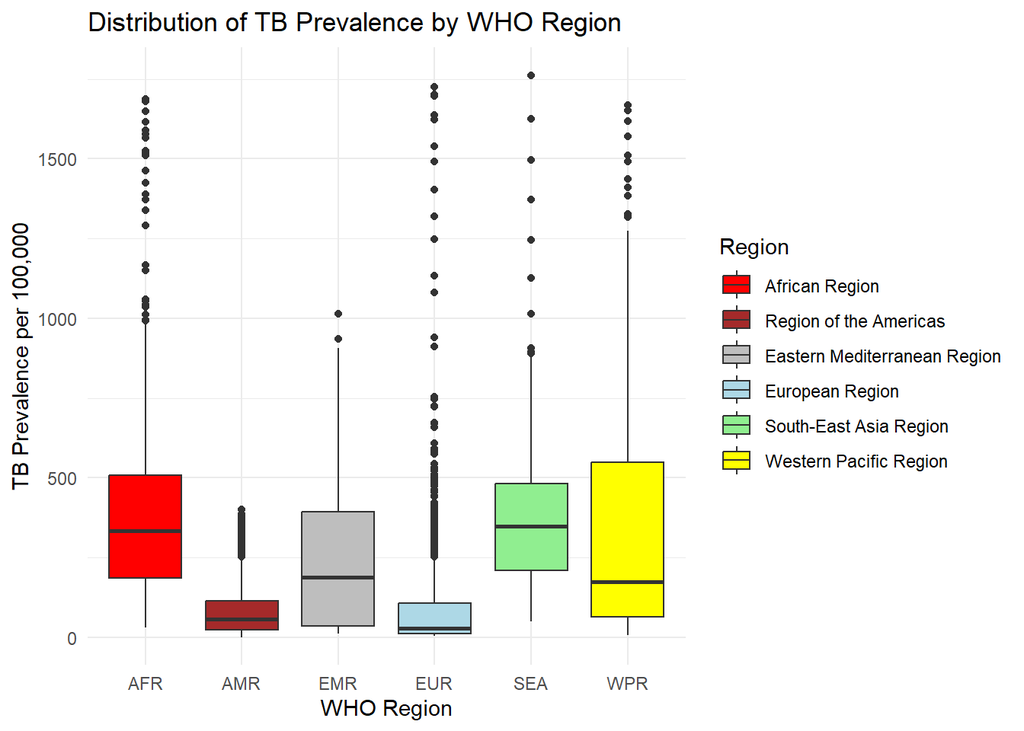

```r
p_box <- ggplot(tb_clean, aes(x = Region, y = `Estimated prevalence of TB (all forms) per 100 000 population`, fill = Region)) +
  geom_boxplot() +
  scale_fill_manual(
    values = c("AFR" = "red",
               "AMR" = "brown",
               "EMR" = "gray",
               "EUR" = "lightblue",
               "SEA" = "lightgreen",
               "WPR" = "yellow"),
    labels = c("AFR" = "African Region",
               "AMR" = "Region of the Americas",
               "EMR" = "Eastern Mediterranean Region",
               "EUR" = "European Region",
               "SEA" = "South-East Asia Region",
               "WPR" = "Western Pacific Region")
  ) +
  labs(title = "Distribution of TB Prevalence by WHO Region",
       x = "WHO Region",
       y = "TB Prevalence per 100,000") +
  theme_minimal()

# Histogram for TB Prevalence across all countries
p_hist <- ggplot(tb_clean, aes(x = `Estimated prevalence of TB (all forms) per 100 000 population`)) +
  geom_histogram(bins = 30, fill = "skyblue", color = "black", alpha = 0.7) +
  labs(title = "Histogram of TB Prevalence",
       x = "TB Prevalence per 100,000",
       y = "Frequency") +
  theme_minimal()
p_box
```

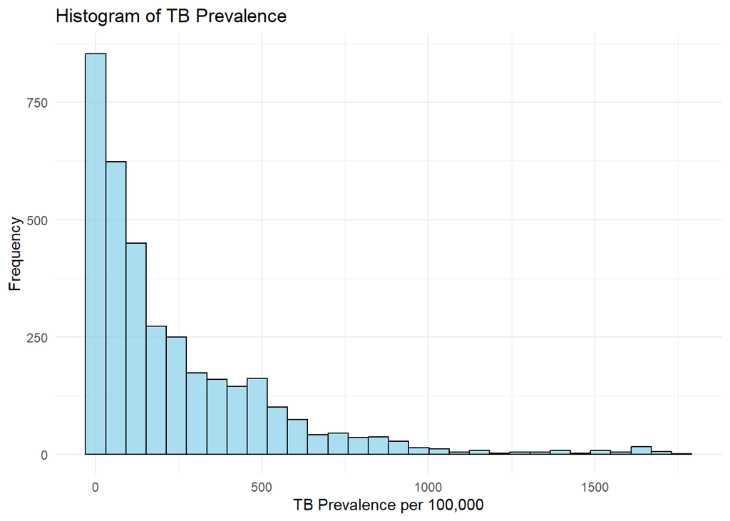

```r
p_hist
```

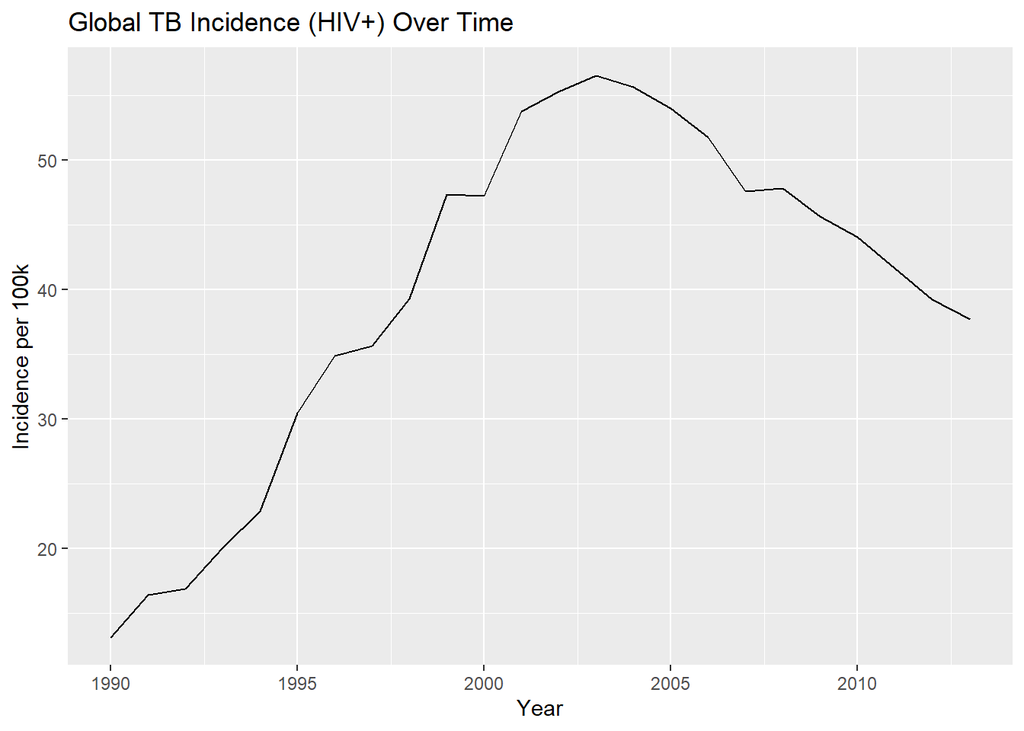

```r
tb_clean %>%
  group_by(Year) %>%
  summarise(global_incidence = mean(`Estimated incidence of TB cases who are HIV-positive per 100 000 population`, na.rm = TRUE)) %>%
  ggplot(aes(x = Year, y = global_incidence)) +
  geom_line() +
  labs(title = "Global TB Incidence (HIV+) Over Time", y = "Incidence per 100k")
```

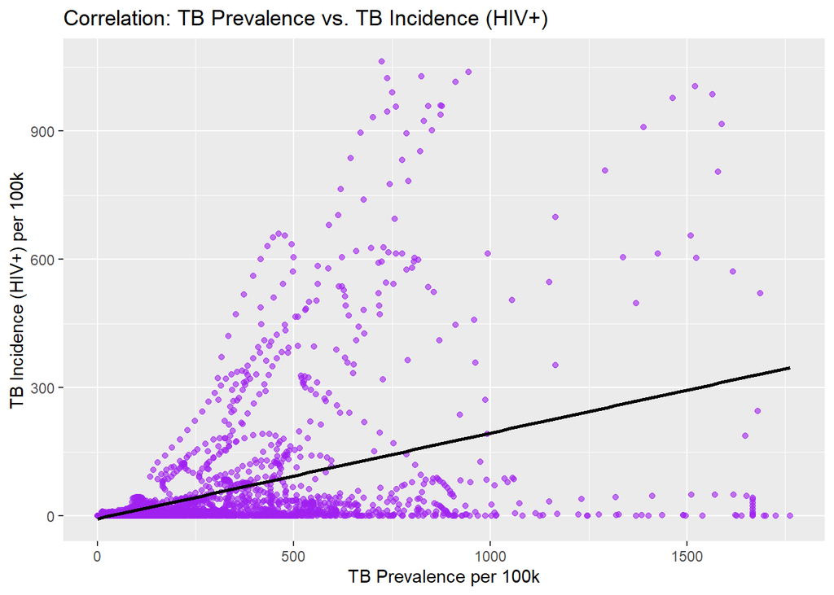

```r
ggplot(tb_clean, aes(x = `Estimated prevalence of TB (all forms) per 100 000 population`,
                     y = `Estimated incidence of TB cases who are HIV-positive per 100 000 population`)) +
  geom_point(alpha = 0.6, color = "purple") +
  geom_smooth(method = "lm", se = FALSE, color = "black") +
  labs(title = "Correlation: TB Prevalence vs. TB Incidence (HIV+)",
       x = "TB Prevalence per 100k", y = "TB Incidence (HIV+) per 100k")
```

## Additional Analyses

*Any additional analysis should be conducted using Tableau.*

# Tableau Story

[figure not shown]

URL Link to Tableau Story Site: [Samuel Nukporfe - Data Viz Project 2](https://public.tableau.com/views/project2_17421703361340/Story1?:language=en-US&publish=yes&:sid=&:redirect=auth&:display_count=n&:origin=viz_share_link)

# References

1. ableau Public [Tableau Help Content]. (2017, February 18). An earthquake trend story. Tableau. Retrieved July 24, 2024, from https://public.tableau.com/app/profile/tableau.docs.team/viz/EarthquakeTrendStory2/Finished-Earthquakestory
2. Tableau Public. (n.d.). Sample Data: Health, TB Burden by Country. Tableau. Retrieved March 10, 2025, from https://public.tableau.com/app/learn/sample-data
3. Canva. (n.d.). Canva [Online graphic design tool]. Retrieved March 16, 2025, from https://www.canva.com
4. RStudio Team. (2022). RStudio: Integrated development for R (Version 2022.07.2) [Computer software]. Posit Software, PBC. Retrieved from https://posit.co
5. St. Joseph Hospital Mysore. (n.d.). TB symbol in hospitals [Image]. Facebook. Retrieved March 16, 2025, from https://www.facebook.com/StJosephHospitalMysore/photos/a.153524453158949/246611290516931/?type=3

# All done!

Knit the completed R Markdown file as a HTML document (click the “Knit” button at the top of the script editor window) and upload it to the submission portal on Canvas.